# 聚焦四大行业,抓住低估值投资机会

大数据驱动投资

QuandlFinance纵横资本

2019-08-21

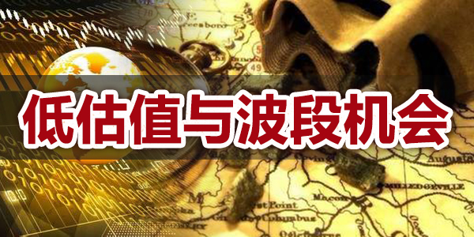

# 投资背景

> 价值投资大师格雷厄姆在其名著《聪明的投资者》中透露,能稳定实现较好投资收益的关键是寻找具有 " 安全边际 " 的公司，即投资价格远低于价值的股票.可以说，找低估值标的进行投资，是一个性价比相对较高的方法，也是极好的买入时机。因为经济的规律总是高低相间，周而复始，一旦经济转好，低估值回到合理估值，就会有极佳的回报. 那么可以关注哪些低估的行业呢？我们一起来看看. 资管新规以后,固收类产品打破刚性兑付,收益持续下降,权益类资产迎来黄金发展周期.权益类基金作为资产配置.基金投资与股票投资相辅相成. 更多内容关注**QuandlFinance**微信公众号.`资讯产品`相关资讯服务.若对**基金投资**不了解的,更多内容参见 @QuandlFinance.

> QuandlFinance好基工作室和 每日金股池

# 银行

[figure not shown]

> 根据申万一级行业市盈率显示的数据,银行业最新的市盈率仅为6.61（8月20日数据）,基本处于历史相对最低位的阶段,具有较高的安全边际. 上半年大部分银行贷款不良率下降，净利润增加，虽然也受到经济下行压力影响,但总体经营稳健,特别是随着下半年货币政策保持流动性合理充裕态势下，业绩仍有提升空间.展望后市，市场整体风险偏好保持低位，银行板块的业绩确定性优势以及部分个股较高的股息率有助于板块估值的稳定,以及保持行业间的相对优势，适合中长期配置. 重点关注股票 招商银行,平安银行,西安银行,兴业银行,建设银行

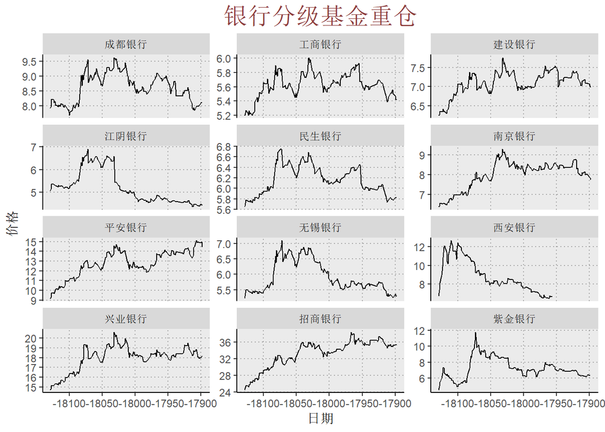

# 通信

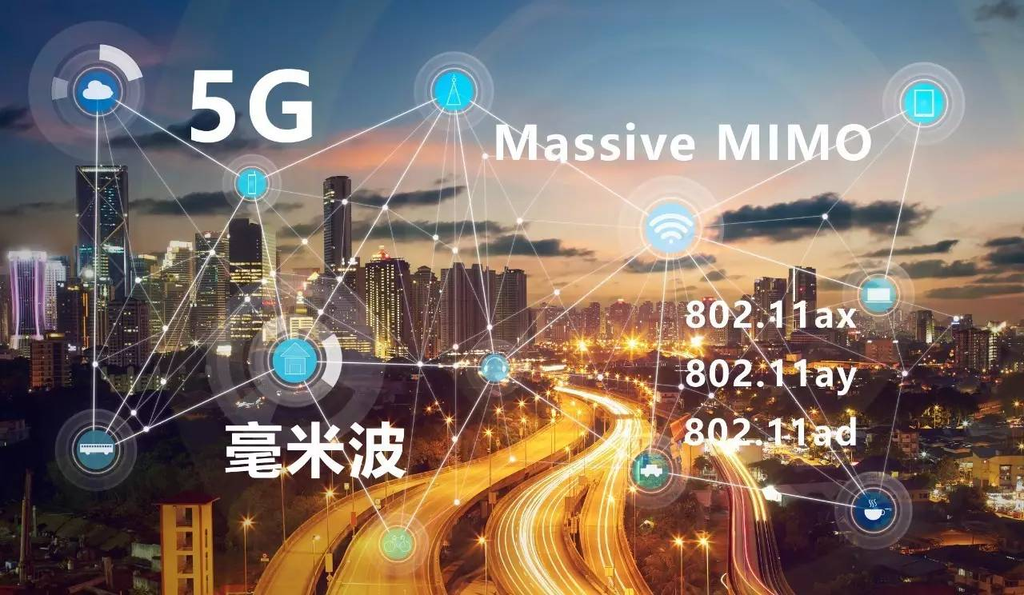

> 自2015年牛市以来，通信设备制造行业估值震荡下行，根据申万一级行业市盈率显示的数据，通信业最新的市盈率仅为38.17（8月20日数据），板块估值处于较低位置，配置正当时。通信行业盈利情况与运营商通信基础设施建设进程密切相关。随着国内5G建设进程提速，运营商资本开始力度提升，通信行业尤其是通信硬件设备制造行业显著受益。展望后市来看，目前，随着5G建设周期的到来，国内频谱分配方案已落地，5G牌照预计2019年下半年发放，运营商资本开支已进入上行周期。通信板块整体估值修复动力比较充足。

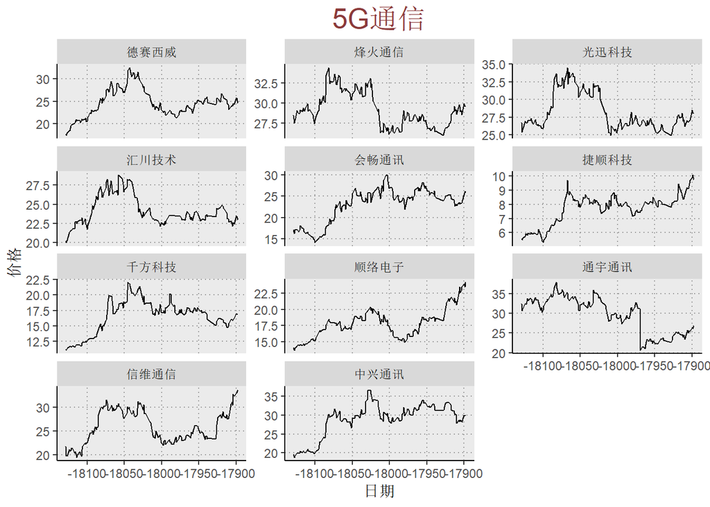

# 传媒

[figure not shown]

> 传媒也是明显低估的行业。根据申万一级行业市盈率显示的数据，传媒业最新的市盈率为29.61（8月20日数据）。

> 回顾过去5年申万传媒指数的PE估值，我们发现历史最高估值出现在15年牛市市场中，而从16年开始，估值持续走低，不断创历史新低。

> 2019年随着传媒板块的诸多负面因素逐步出清，风险正在得到释放，板块估值虽然有所提升，但仍然处在历史低位区间。中长期仍然以关注各细分领域的龙头公司为主，建议以国家政策为线索，持续关注国有媒体改革和广电板块投资机会，但也需高度警惕股价短期过快上涨的潜在风险。

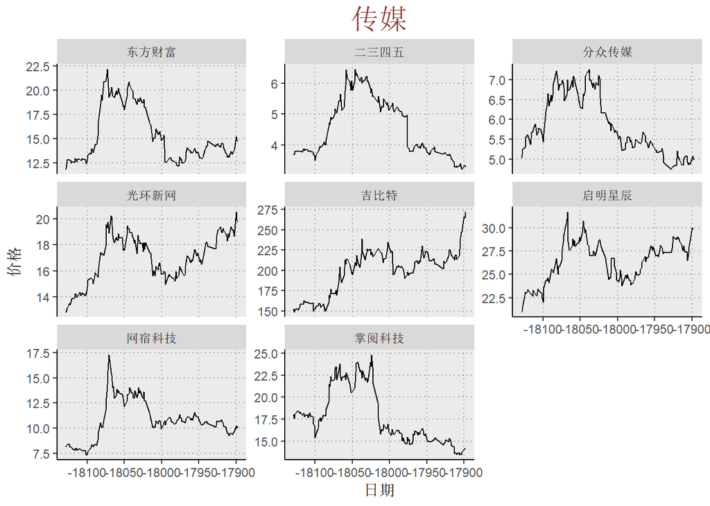

# 医药生物

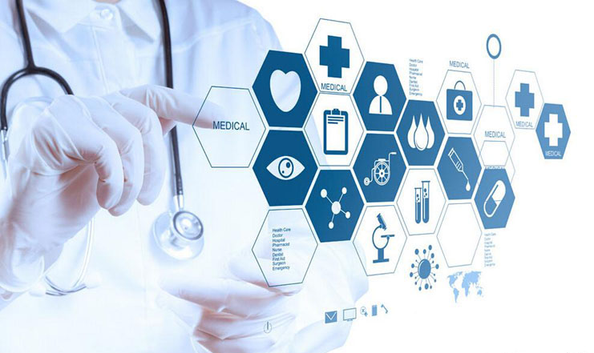

> 根据申万一级行业市盈率显示的数据，目前，医药生物行业的市盈率仅为30.67（8月20日数据），处于历史底部区间，后续发展空间可期。 医药行业是一个兼具健康需求属性和消费属性的行业，随着我们人均可支配收入的提升和整个医保政策的健全，消费者有意愿也有能力持续的为自己的健康来买单，这个是医药行业长期发展的最核心的内在驱动力。 随着医药行业供给侧改革进一步深化，行业集中度逐步提升，仿制药及高值类耗材价格下行大势所趋，具有突出临床价值的创新药品种或将长期受益，行业整体估值修复动力比较充足。

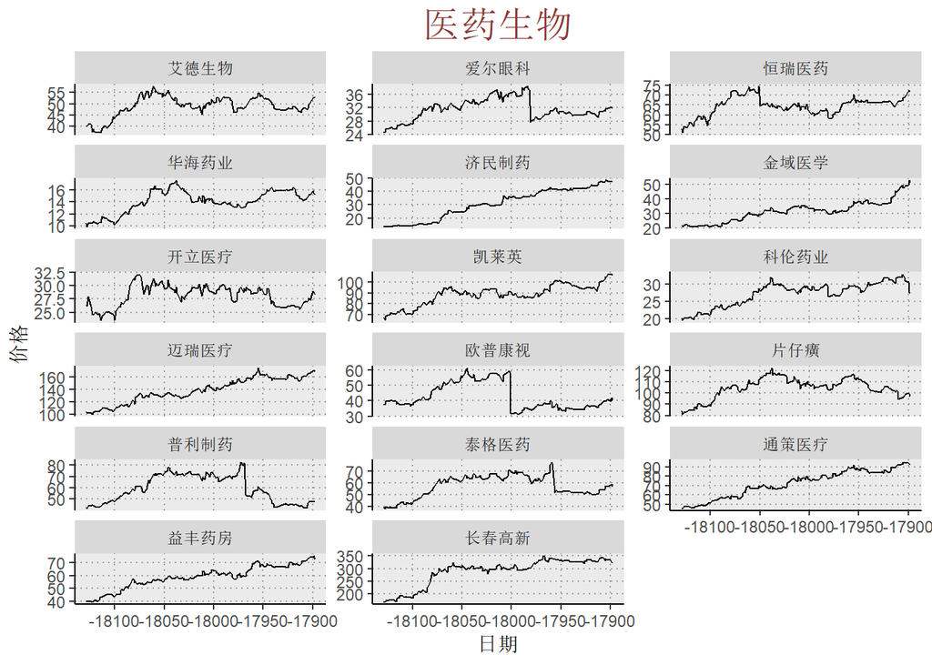

```
风险最大时,也是机遇最大时.别人恐惧时,我们要贪婪！！
```

# 本周投资策略

> 以改革促降息，科技股积极可为 内外部环境仍相对温和，积极信号进一步增多，结构性机会积极可为：外部环境看，美国期限利差倒挂预示美国经济下行压力和美国波动压力，对A股影响有限。内部环境看，LPR机制形成，以利率市场化改革方式促降息，有望引导实体经济融资成本下行，叠加减税降费等政策效果的逐步显现，企业成本费用端压力有望进一步降低，市场风险偏好有望改善；8月以来，国内长端利率明显下行，创2017年以来新低。配置上，继续推荐科技股+汽车，优选华为产业链+半导体产业链。

# 投资大师的成功法则

大师最初也是初学者,跟随大师的脚步才能快速成长.

> “集中投资就是计划生育:股票越少，组合业绩越好;长期持有就是龟兔赛跑:长期内复利可以战胜一切;”

# 投资建议

> 1 采用金字塔式投资策略,震荡的行情中按比例1:2:3:4分布建仓！

> 2 延长持有周期,追求一定周期内的绝对投资回报！

> 3 投资有风险,投资需谨慎！！